# R Notebook

# we’ll also remove the region - consumers don’t take to look at item provenance

```r
avocado_trim <- avocado %>%
  mutate(total_sales = (av_price * tot_vol)) %>%
  mutate(other_bags = (tot_bags - (S_bags + L_bags + XL_bags))) %>%
  gather(bag_size, bag_quantity, c(S_bags, L_bags, XL_bags, other_bags)) %>%
  mutate(other_cat = (tot_vol - (cat_plu4046 + cat_plu4225 + cat_plu4770))) %>%
  gather(category, num_avocado,
         c(cat_plu4046, cat_plu4225, cat_plu4770, other_cat)) %>%
  mutate(month = month(date)) %>%
  mutate(year = (year)) %>%
  select(-c(tot_bags, date, id, bags, volume, av_price, tot_vol, region))
```

```r
glimpse(avocado_trim)
```

```
Observations: 291,984
Variables: 8
$ type         <chr> "conventional", "conventional", "conventional", "conventional", "conventional…
$ year         <dbl> 2015, 2015, 2015, 2015, 2015, 2015, 2015, 2015, 2015, 2015, 2015, 2015, 2015,…
$ total_sales  <dbl> 85434.70, 74083.92, 109944.80, 85311.52, 65330.69, 70534.52, 82619.22, 107239…
$ bag_size     <chr> "S_bags", "S_bags", "S_bags", "S_bags", "S_bags", "S_bags", "S_bags", "S_bags…
$ bag_quantity <dbl> 8603.62, 9408.07, 8042.21, 5677.40, 5986.26, 6556.47, 8196.81, 6266.85, 11104…
$ category     <chr> "cat_plu4046", "cat_plu4046", "cat_plu4046", "cat_plu4046", "cat_plu4046", "c…
$ num_avocado  <dbl> 1036.74, 674.28, 794.70, 1132.00, 941.48, 1184.27, 1368.92, 703.75, 1022.15, …
$ month        <dbl> 12, 12, 12, 12, 11, 11, 11, 11, 11, 10, 10, 10, 10, 9, 9, 9, 9, 8, 8, 8, 8, 8…
```

Let’s split the data into train and test

```r
n_data <- nrow(avocado_trim)
test_index <- sample(1:n_data, size = n_data*0.2)

test  <- slice(avocado_trim, test_index)
train <- slice(avocado_trim, -test_index)
```

Finding the best model Let’s comapre the best models to predict the sales of avocado using the different type of methods:

```r
library(leaps)
```

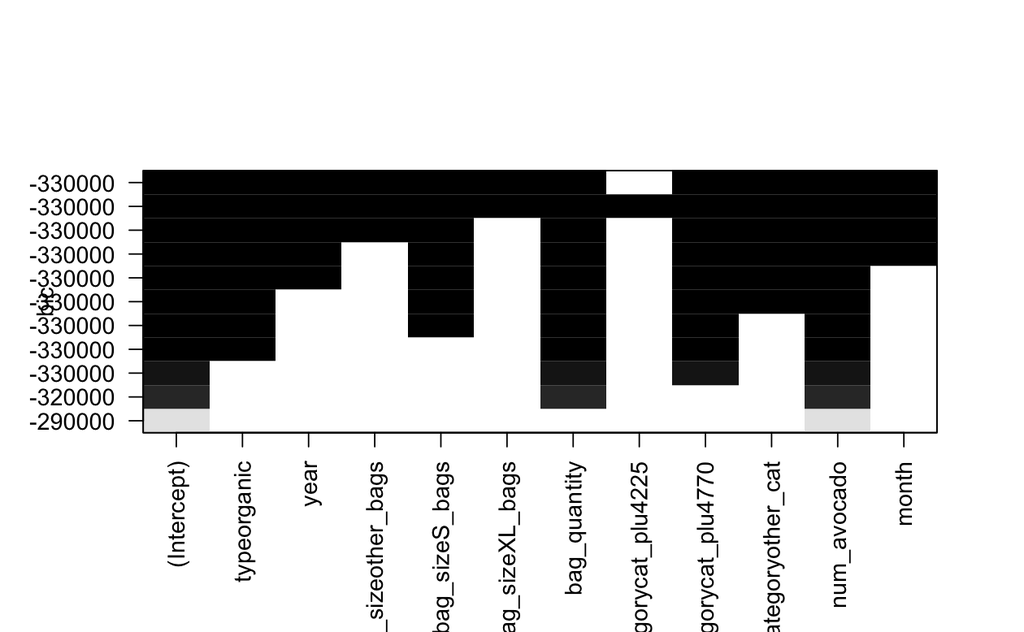

```r
regsubsets_forward <- regsubsets(total_sales ~ .,
                                 data = train, nvmax = 11,
                                 method = "forward")
sum_regsubsets_forward <- summary(regsubsets_forward)

plot(regsubsets_forward, scale = "bic")
```

num_avocado - bag_quantity - plu4770 - typeorganic - sizeS_bag - other_cat - year - month - other bag - plu4225 - XL_bags

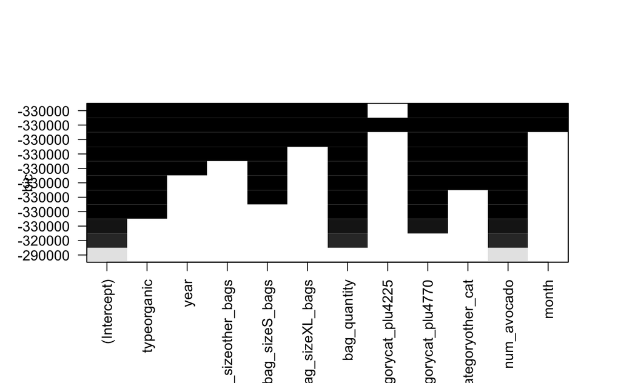

```r
regsubsets_back <- regsubsets(total_sales ~ .,
                                 data = train, nvmax = 11,
                                 method = "backward")
sum_regsubsets_back <- summary(regsubsets_back)

plot(regsubsets_back, scale = "bic")
```

num_avocado - bag_quantity - plu4770 - typeorganic - sizeS_bag - other_cat - year - other bag - XL_bags -plu 4225 - month

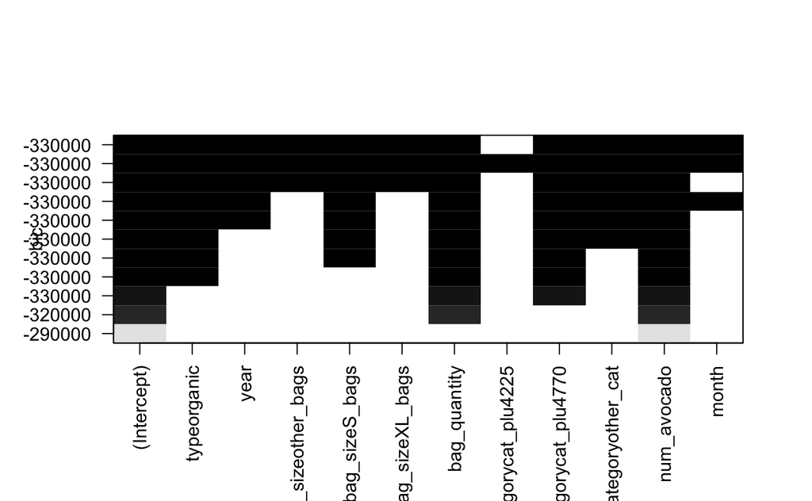

```r
regsubsets_subset <- regsubsets(total_sales ~ .,
                                 data = train, nvmax = 11,
                                 method = "exhaustive")
sum_regsubsets_subset <- summary(regsubsets_subset)

plot(regsubsets_subset, scale = "bic")
```

num_avocado - bag_quantity - plu4770 - typeorganic - sizeS_bag - other_cat - year - other bag - XL_bags -plu 4225 - month

Let’s plot the bic

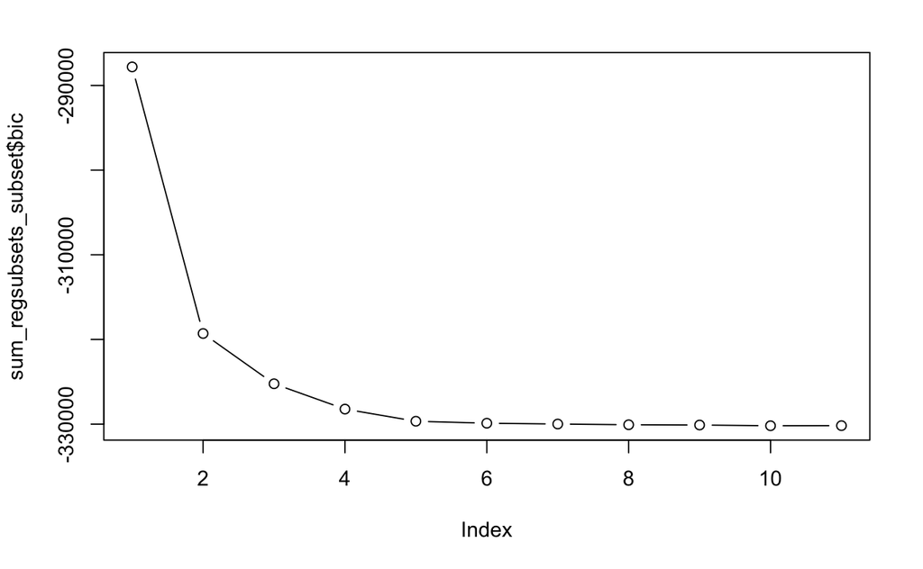

```r
plot(sum_regsubsets_subset$bic, type = "b")
```

We can see that 5 parameters should be enough. The first 5 categories are - num_avocado - bag_quantity - plu4770 (category of avocado) - typeorganic - sizeS_bag (ccategory of bags)

Not all cat of bags or avocados are included. Let’s start with a model with only three predicting variables

```r
colnames(avocado_trim)
```

```
[1] "type"         "year"         "total_sales"  "bag_size"     "bag_quantity" "category"
[7] "num_avocado"  "month"
```

Let’s create the model:

```r
mod1_3var <- lm(total_sales ~ num_avocado + bag_quantity + type,
                data = train)
```

```r
summary(mod1_3var)
```

```
Call:
lm(formula = total_sales ~ num_avocado + bag_quantity + type,
    data = train)

Residuals:
      Min        1Q    Median        3Q       Max
-38648670   -354457    -30424    -10083  50566603

Coefficients:
               Estimate Std. Error t value Pr(>|t|)
(Intercept)   4.685e+05  5.669e+03   82.63   <2e-16 ***
num_avocado   2.622e+00  4.468e-03  586.79   <2e-16 ***
bag_quantity  2.033e+00  1.114e-02  182.51   <2e-16 ***
typeorganic  -4.375e+05  7.836e+03  -55.83   <2e-16 ***
---
Signif. codes:  0 ‘***’ 0.001 ‘**’ 0.01 ‘*’ 0.05 ‘.’ 0.1 ‘ ’ 1

Residual standard error: 1855000 on 233584 degrees of freedom
Multiple R-squared:  0.7485,    Adjusted R-squared:  0.7485
F-statistic: 2.317e+05 on 3 and 233584 DF,  p-value: < 2.2e-16
```

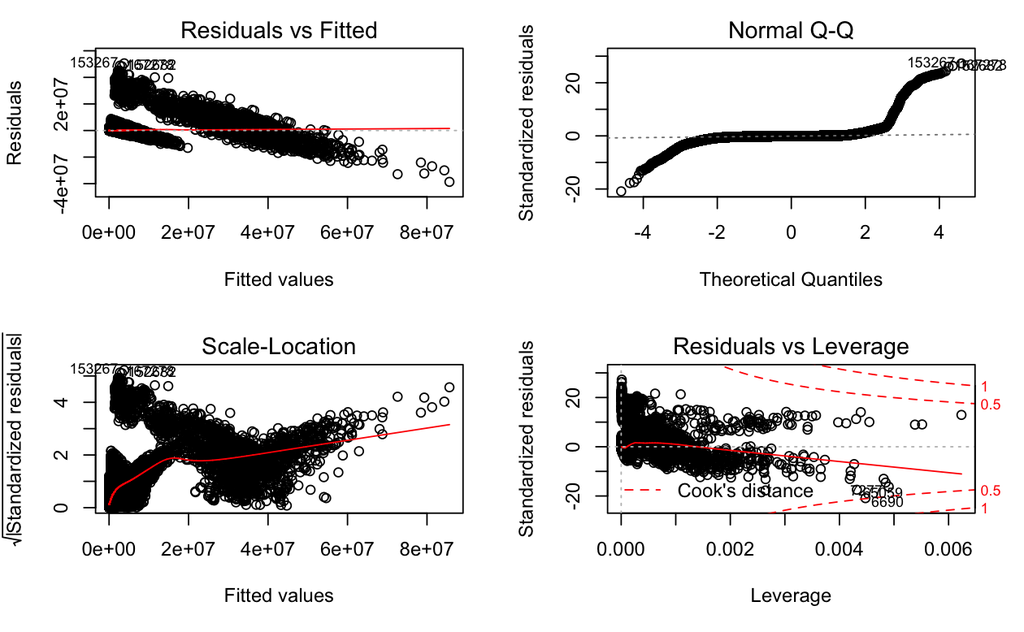

```r
par(mfrow = c(2, 2))
plot(mod1_3var)
```

Modifying the sales (log or squared) did not help Let’s see if adding another variable will help From the BIC analysis the type of avocado or the type of bags might affect the model. Let’s create the models and see the statistical significance of adding the categorical variables with an anova

```r
mod2a_4var <- lm(total_sales ~ num_avocado + bag_quantity + type + category,
                data = train)

mod2b_4var <- lm(total_sales ~ num_avocado + bag_quantity + type + bag_size,
                data = train)
```

```r
summary(mod2a_4var)
```

```
Call:
lm(formula = total_sales ~ num_avocado + bag_quantity + type +
    category, data = train)

Residuals:
      Min        1Q    Median        3Q       Max
-38742421   -468540    -39702    192360  50036351

Coefficients:
                      Estimate Std. Error t value Pr(>|t|)
(Intercept)          2.417e+05  8.688e+03  27.822   <2e-16 ***
num_avocado          2.668e+00  4.448e-03 599.685   <2e-16 ***
bag_quantity         1.975e+00  1.102e-02 179.321   <2e-16 ***
typeorganic         -4.251e+05  7.736e+03 -54.947   <2e-16 ***
categorycat_plu4225 -9.577e+03  1.072e+04  -0.894    0.372
categorycat_plu4770  7.237e+05  1.078e+04  67.151   <2e-16 ***
categoryother_cat    1.416e+05  1.072e+04  13.216   <2e-16 ***
---
Signif. codes:  0 ‘***’ 0.001 ‘**’ 0.01 ‘*’ 0.05 ‘.’ 0.1 ‘ ’ 1

Residual standard error: 1831000 on 233581 degrees of freedom
Multiple R-squared:  0.755, Adjusted R-squared:  0.755
F-statistic: 1.2e+05 on 6 and 233581 DF,  p-value: < 2.2e-16
```

```r
anova(mod1_3var, mod2a_4var)
```

```
Analysis of Variance Table

Model 1: total_sales ~ num_avocado + bag_quantity + type
Model 2: total_sales ~ num_avocado + bag_quantity + type + category
  Res.Df        RSS Df  Sum of Sq      F    Pr(>F)
1 233584 8.0343e+17
2 233581 7.8270e+17  3 2.0729e+16 2062.1 < 2.2e-16 ***
---
Signif. codes:  0 ‘***’ 0.001 ‘**’ 0.01 ‘*’ 0.05 ‘.’ 0.1 ‘ ’ 1
```

The addition of the type of avocado appears to be statistically significant

```r
summary(mod2b_4var)
```

```
Call:
lm(formula = total_sales ~ num_avocado + bag_quantity + type +
    bag_size, data = train)

Residuals:
      Min        1Q    Median        3Q       Max
-39176137   -337766   -139192     59800  50441575

Coefficients:
                     Estimate Std. Error t value Pr(>|t|)
(Intercept)         4.776e+05  8.718e+03   54.78   <2e-16 ***
num_avocado         2.602e+00  4.479e-03  580.95   <2e-16 ***
bag_quantity        2.131e+00  1.136e-02  187.56   <2e-16 ***
typeorganic        -4.346e+05  7.809e+03  -55.65   <2e-16 ***
bag_sizeother_bags  1.151e+05  1.084e+04   10.62   <2e-16 ***
bag_sizeS_bags     -2.744e+05  1.091e+04  -25.14   <2e-16 ***
bag_sizeXL_bags     1.103e+05  1.084e+04   10.18   <2e-16 ***
---
Signif. codes:  0 ‘***’ 0.001 ‘**’ 0.01 ‘*’ 0.05 ‘.’ 0.1 ‘ ’ 1

Residual standard error: 1848000 on 233581 degrees of freedom
Multiple R-squared:  0.7503,    Adjusted R-squared:  0.7502
F-statistic: 1.169e+05 on 6 and 233581 DF,  p-value: < 2.2e-16
```

If we keep model2a and add the type of bags used:

```r
mod3_5var <- lm(total_sales ~ num_avocado + bag_quantity + type + category + bag_size, data = train)

summary(mod3_5var)
```

```
Call:
lm(formula = total_sales ~ num_avocado + bag_quantity + type +
    category + bag_size, data = train)

Residuals:
      Min        1Q    Median        3Q       Max
-39255564   -441370    -79309    171387  49917710

Coefficients:
                      Estimate Std. Error t value Pr(>|t|)
(Intercept)          2.516e+05  1.086e+04  23.160   <2e-16 ***
num_avocado          2.648e+00  4.460e-03 593.730   <2e-16 ***
bag_quantity         2.072e+00  1.124e-02 184.296   <2e-16 ***
typeorganic         -4.223e+05  7.710e+03 -54.768   <2e-16 ***
categorycat_plu4225 -9.446e+03  1.068e+04  -0.884    0.377
categorycat_plu4770  7.187e+05  1.074e+04  66.913   <2e-16 ***
categoryother_cat    1.407e+05  1.068e+04  13.176   <2e-16 ***
bag_sizeother_bags   1.124e+05  1.070e+04  10.507   <2e-16 ***
bag_sizeS_bags      -2.666e+05  1.077e+04 -24.746   <2e-16 ***
bag_sizeXL_bags      1.085e+05  1.070e+04  10.139   <2e-16 ***
---
Signif. codes:  0 ‘***’ 0.001 ‘**’ 0.01 ‘*’ 0.05 ‘.’ 0.1 ‘ ’ 1

Residual standard error: 1824000 on 233578 degrees of freedom
Multiple R-squared:  0.7567,    Adjusted R-squared:  0.7566
F-statistic: 8.07e+04 on 9 and 233578 DF,  p-value: < 2.2e-16
```

```r
anova(mod2a_4var, mod3_5var)
```

```
Analysis of Variance Table

Model 1: total_sales ~ num_avocado + bag_quantity + type + category
Model 2: total_sales ~ num_avocado + bag_quantity + type + category +
    bag_size
  Res.Df       RSS Df  Sum of Sq     F    Pr(>F)
1 233581 7.827e+17
2 233578 7.774e+17  3 5.2939e+15 530.2 < 2.2e-16 ***
---
Signif. codes:  0 ‘***’ 0.001 ‘**’ 0.01 ‘*’ 0.05 ‘.’ 0.1 ‘ ’ 1
```

It appears statistically significant, however du to the little improvement in the adjusted R_squared, it might be best to keep model 2a. Let’s see if we can add some interaction for the continuous variables

```r
mod4_4var <- mod3_5var <- lm(total_sales ~ num_avocado + bag_quantity + type
                             + category + num_avocado:bag_quantity,
                             data = train)
summary(mod4_4var)
```

```
Call:
lm(formula = total_sales ~ num_avocado + bag_quantity + type +
    category + num_avocado:bag_quantity, data = train)

Residuals:
      Min        1Q    Median        3Q       Max
-19466579   -433203     34891    201608  49535533

Coefficients:
                           Estimate Std. Error  t value Pr(>|t|)
(Intercept)               4.469e+04  8.243e+03    5.422  5.9e-08 ***
num_avocado               2.912e+00  4.408e-03  660.801  < 2e-16 ***
bag_quantity              3.961e+00  1.533e-02  258.334  < 2e-16 ***
typeorganic              -2.365e+05  7.350e+03  -32.177  < 2e-16 ***
categorycat_plu4225      -1.596e+04  1.007e+04   -1.584    0.113
categorycat_plu4770       7.067e+05  1.013e+04   69.767  < 2e-16 ***
categoryother_cat         1.384e+05  1.007e+04   13.740  < 2e-16 ***
num_avocado:bag_quantity -2.831e-07  1.612e-09 -175.575  < 2e-16 ***
---
Signif. codes:  0 ‘***’ 0.001 ‘**’ 0.01 ‘*’ 0.05 ‘.’ 0.1 ‘ ’ 1

Residual standard error: 1721000 on 233580 degrees of freedom
Multiple R-squared:  0.7836,    Adjusted R-squared:  0.7836
F-statistic: 1.208e+05 on 7 and 233580 DF,  p-value: < 2.2e-16
```

```r
anova(mod2a_4var, mod4_4var)
```

```
Analysis of Variance Table

Model 1: total_sales ~ num_avocado + bag_quantity + type + category
Model 2: total_sales ~ num_avocado + bag_quantity + type + category +
    num_avocado:bag_quantity
  Res.Df        RSS Df  Sum of Sq     F    Pr(>F)
1 233581 7.8270e+17
2 233580 6.9145e+17  1 9.1253e+16 30827 < 2.2e-16 ***
---
Signif. codes:  0 ‘***’ 0.001 ‘**’ 0.01 ‘*’ 0.05 ‘.’ 0.1 ‘ ’ 1
```

Checking the results above with glmulti

Unfortunately it didn’t work :(

Let’s check how the model performs on the test set

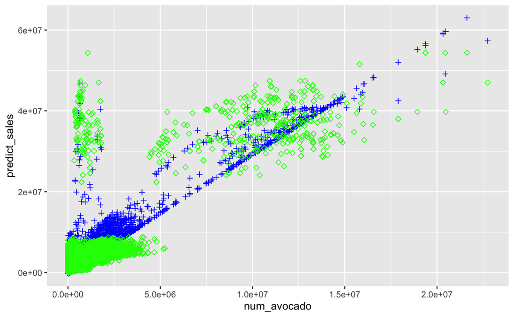

```r
predictions <- predict(mod4_4var, newdata = test)
predict_and_actual <- test %>%
  mutate(predict_sales = predictions) %>%
  mutate(residuals = (sqrt((predict_sales - total_sales) ** 2))) %>%
  select(total_sales, predict_sales, residuals, num_avocado)

ggplot(predict_and_actual) +
  geom_point(aes(x = num_avocado, y = predict_sales),
             colour = "blue",
             shape = 3) +
  geom_point(aes(x = num_avocado, y = total_sales),
             colour = "green",
             shape = 5)
```

```r
mean(sum(predict_and_actual$residuals))
```

```
[1] 31712493600
```

That’s not great! but the graph doesn’t look too far off…

K-fold chack on the whole data set

```r
library(caret)
cv_10_fold <- trainControl(method = "cv", number = 10, savePredictions = TRUE)

model <- train(total_sales ~ .,
               data = avocado_trim,
               trControl = cv_10_fold,
               method = 'lm')
```

```r
mean(model$resample$RMSE)
```

```
[1] 1809863
```

```r
mean(model$resample$Rsquared)
```

```
[1] 0.7584688
```

Comparison to model : mod4_4var

```r
cv_10_fold_2 <- trainControl(method = "cv", number = 10, savePredictions = TRUE)

model_2 <- train(total_sales ~ num_avocado + bag_quantity + type
                             + category + num_avocado:bag_quantity,
               data = avocado_trim,
               trControl = cv_10_fold_2,
               method = 'lm')
```

```r
mean(model_2$resample$RMSE)
```

```
[1] 1711318
```

```r
mean(model_2$resample$Rsquared)
```

```
[1] 0.7843726
```

So the model desined with the 4 vriables and the interaction is actually not too bad.